# Лабораторная работа №8

Редактор vi

Рогожина Н.А.

Российский университет дружбы народов, Москва, Россия

01 апреля 2023

# Информация

## Докладчик

- Рогожина Надежда Александровна
- Студентка 1го курса, НКАбд-02-22
- Компьютерные и информационные науки
- Российский университет дружбы народов
- [Github](https://github.com/MikoGreen/study_2022-2023_os-intro)

# Вводная часть

## Актуальность

- Текстовый редактор vi установлен по умолчанию практически во всех дистрибутивах, следовательно умение пользоваться им значительно расширит количество дистрибутивов вашего портфолио.

## Объект и предмет исследования

- Текстовый редактор vi

## Цели и задачи

- Познакомиться с операционной системой Linux. Получить практические навыки работы с редактором vi, установленным по умолчанию практически во всех дистрибутивах.

# Содержание лабораторной работы

## Создание нового файла с использованием vi

Вызовем vi и создайте файл hello.sh:

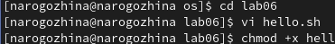

Вызов vi

## Создание нового файла с использованием vi

Нажмем клавишу i и введем следующий текст:

```
1 #!/bin/bash
2 HELL=Hello
3 function hello {
4 LOCAL HELLO=World
5 echo $HELLO
6 }
7 echo $HELLO
8 hello
```

## Создание нового файла с использованием vi

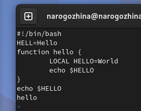

Редактирование файла

## Создание нового файла с использованием vi

Нажмем клавишу Esc для перехода в командный режим после завершения ввода текста и “:” для перехода в режим последней строки и внизу вашего экрана появится приглашение в виде двоеточия:

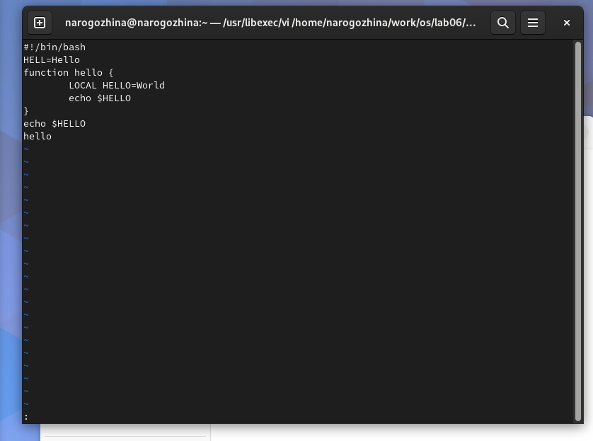

Переход в командный режим

## Создание нового файла с использованием vi

Нажмем w (записать) и q (выйти), а затем нажмем клавишу Enter для сохранения вашего текста и завершения работы:

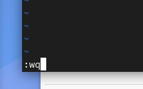

Сохранение и выход из файла

## Редактирование существующего файла

1. Вызовите vi на редактирование файла:

```
1 vi ~/work/os/lab06/hello.sh
```

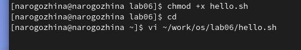

vi ~/work/os/lab06/hello.sh

## Редактирование существующего файла

Перейдем в режим вставки и замените на HELLO. Нажмем Esc для возврата в командный режим:

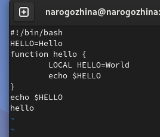

Изменение слова

## Редактирование существующего файла

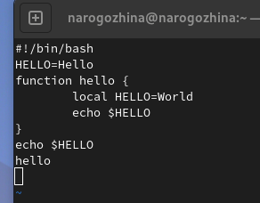

## Редактирование существующего файла

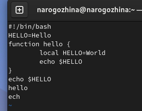

# Выводы

## Выводы

В ходе выполнения лабораторной работы мы научились пользоваться с редактором vi, установленным по умолчанию практически во всех дистрибутивах Linux.